# Analyses for all gfsynopsis species

Andrew Edwards

This vignette extracts, analyses, saves and plots the data for all (>100) species for the gfsynopsis reports, plus “hooks with bait” considered as a species. It only runs for users with access to the GFBio database at the Pacific Biological Station, or if you have the retrieved data cached locally (in default directory `all-species-data/`. Species names are now searchable in the resulting .html file (that you may well be reading now).

These analyses ignore hook competition, though it is likely important given the final plot of the rate of hooks returned with bait (showing how this jumps around), and given our simulation results in [Watson et al. (2023)](https://cdnsciencepub.com/doi/full/10.1139/cjfas-2022-0159). We are looking at incorporating hook competition in the next groundfish synopsis report.

```r
library(gfiphc)
```

## Data for all species for gfsynopsis reports

Define common species name:

```r
sp_vec <- gfsynopsis::get_spp_names() %>%
  dplyr::arrange(species_code) %>%
  dplyr::pull(species_common_name)
sp_vec <- c(sp_vec, "hook with bait")
```

Extract the data, create the four time Series A, B, C and D, compare them, and plot the results, for all species (will take some time). Series AB (bottom right panel), if shown, will be the longest time series that can be calculated and will be representative of the full coast (others might be longest for rarer species). If it is empty then one of the other time series is the longest. For rarer species with low catch rates, it may make more sense to consider Series B instead of Series AB.

Change the options to use the cached data and cached results (for example, set both to `FALSE` when first running; can see the files appearing in the cache folders species by species, took about an hour for 2022 data):

```
#> [1] "***** bluntnose sixgill shark *****"
```

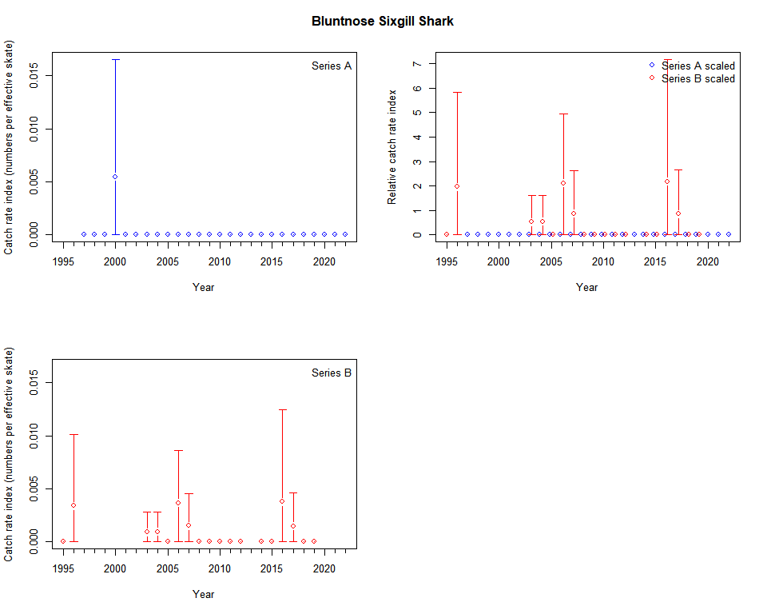

```
#> [1] "***** basking shark *****"
```

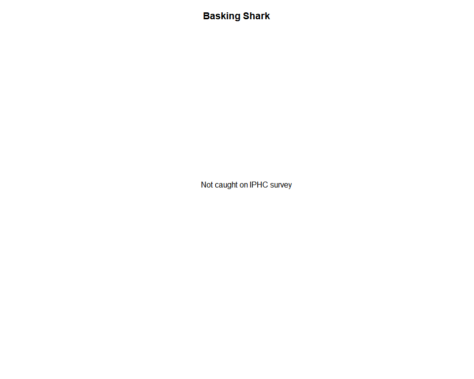

```
#> [1] "***** salmon shark *****"
```

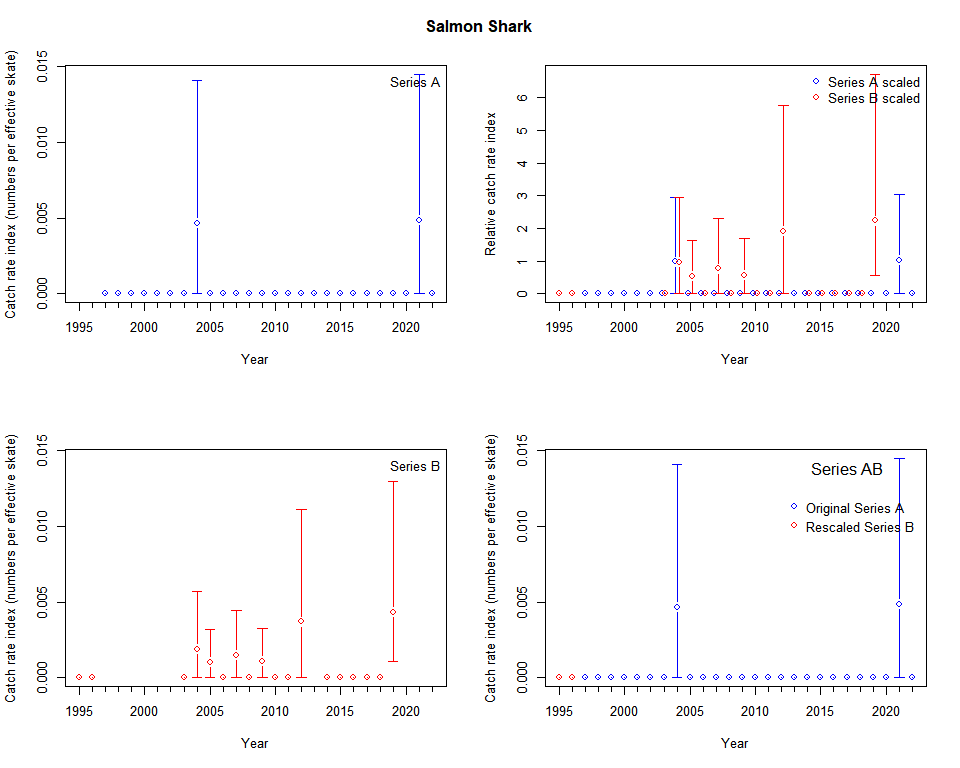

```
#> [1] "***** brown cat shark *****"
```

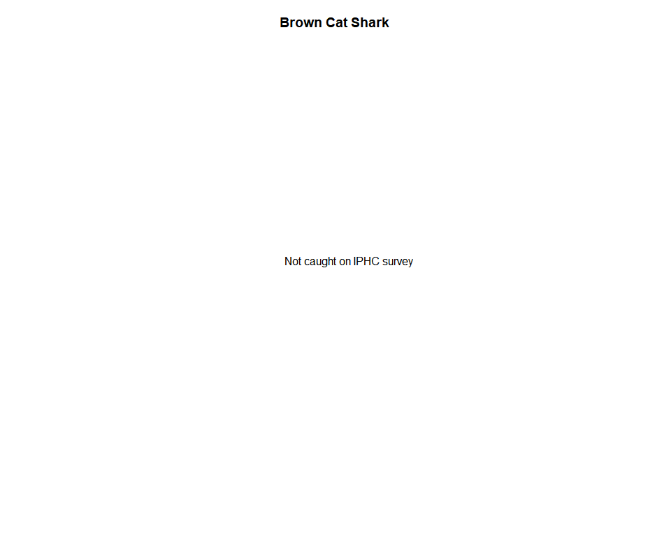

```
#> [1] "***** tope shark *****"
```

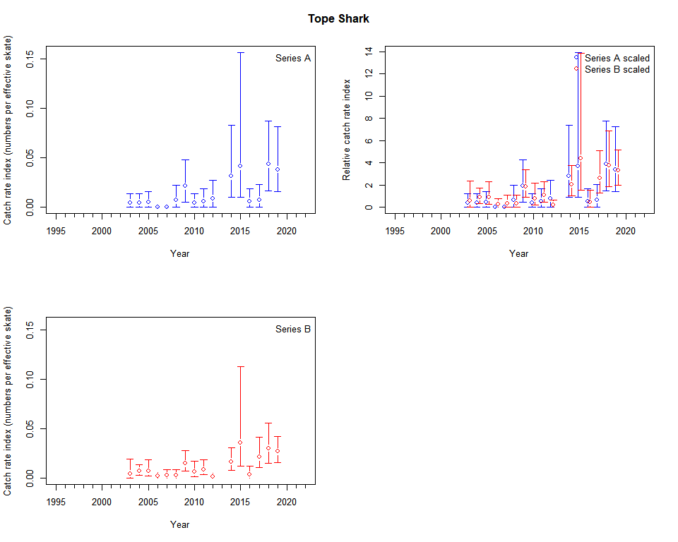

```
#> [1] "***** blue shark *****"
```

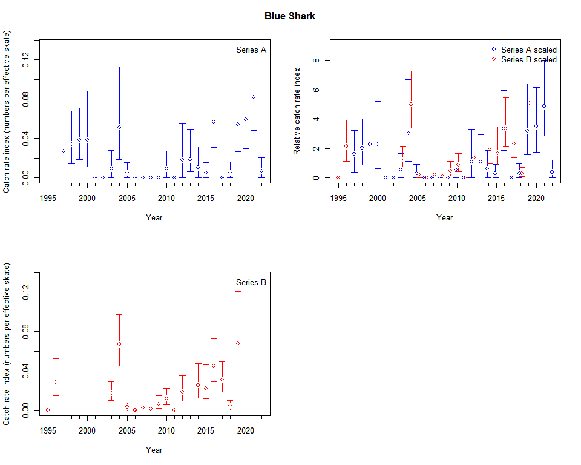

```
#> [1] "***** pacific sleeper shark *****"
```

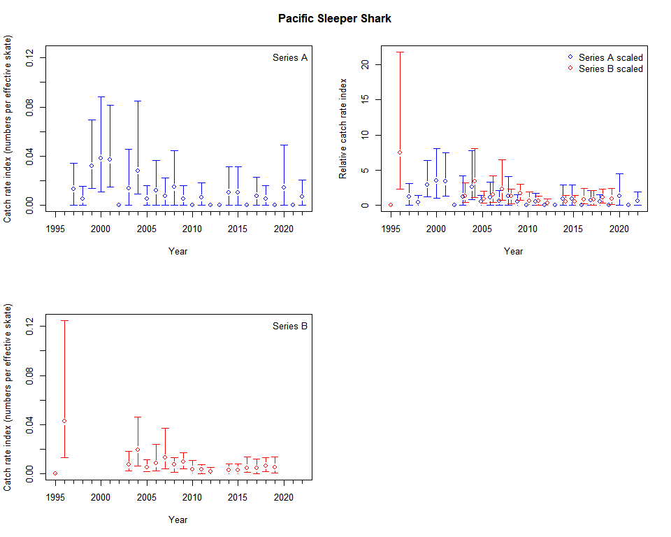

```
#> [1] "***** north pacific spiny dogfish *****"
```

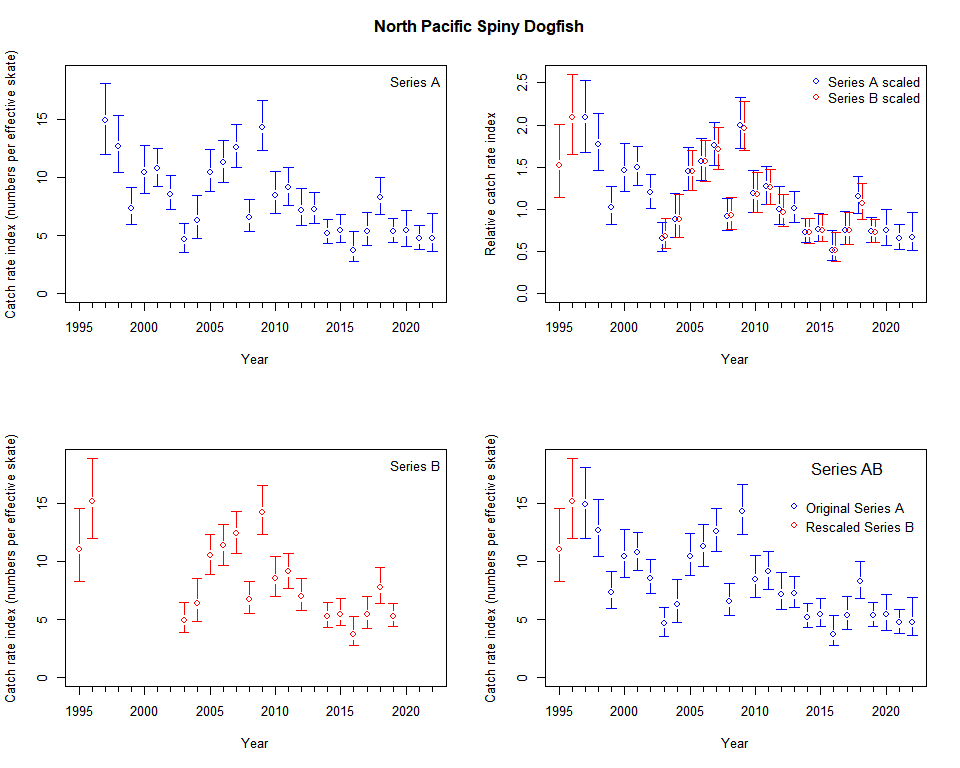

```
#> [1] "***** aleutian skate *****"
```

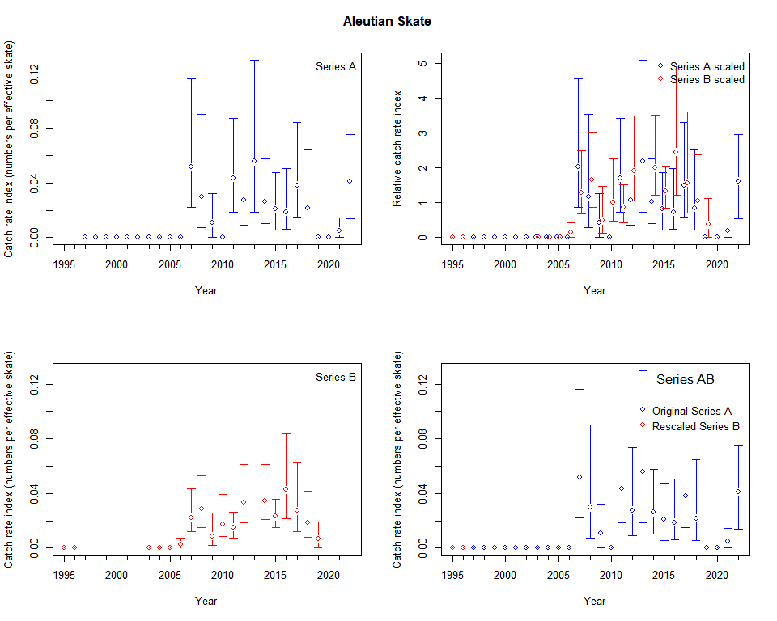

```
#> [1] "***** abyssal skate *****"
```

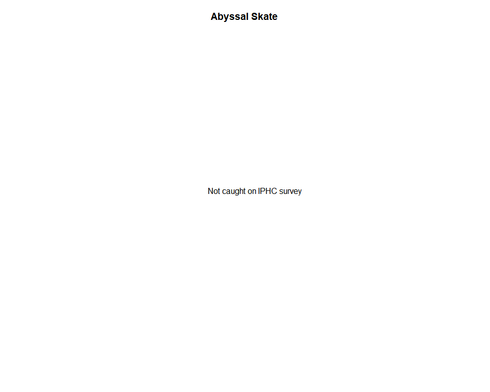

```
#> [1] "***** broad skate *****"
```

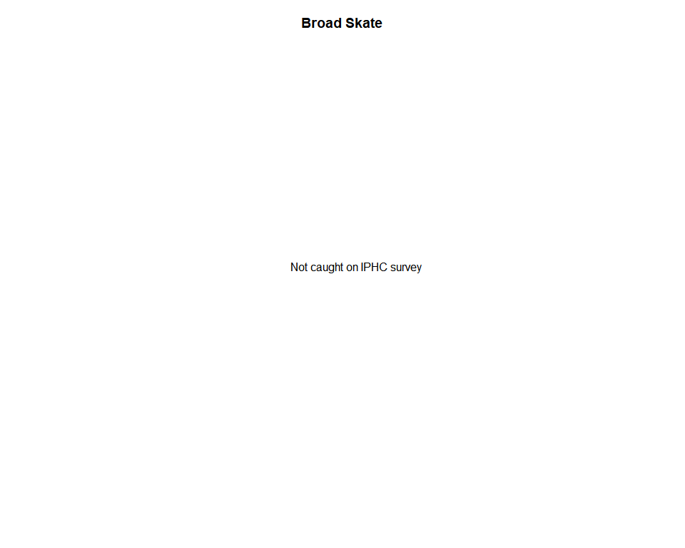

```
#> [1] "***** big skate *****"
```

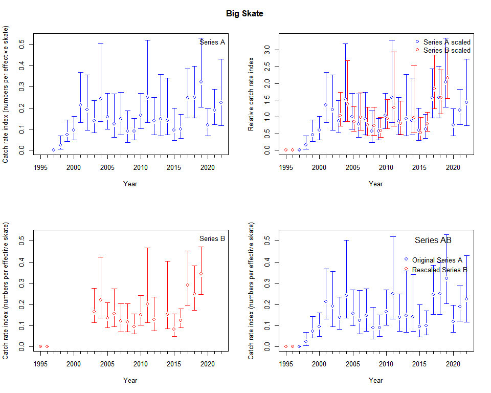

```
#> [1] "***** roughtail skate *****"
```

[102 more figures not shown]

```r
for(sp in sp_vec){      # increment these to test, done up to number shown
  iphc_get_calc_plot_full(sp,
                          cached_data = TRUE,    # TRUE if data already saved
                          cached_results = TRUE, # TRUE if results already saved
                          print_sp_name = TRUE,
                          path_data = "all-species-data",
                          path_results = "all-species-results")
}
```

```r
# For investigating and checking:
# If results saved:
# series_ABCD_full <- readRDS(paste0("all-species-results/", sp_hyphenate(sp, results = TRUE)))$series_ABCD_full
#
# Else load data and do calculations:
# sp_set_counts <- readRDS(paste0("all-species-data", "/", sp_hyphenate(sp)))
# series_ABCD_full <- calc_iphc_full_res(sp_set_counts$set_counts)
#
# which(sp_vec == sp)
```